# R visualization class project

Neha Gupta

5/19/2019

I am a postdoctoral fellow at NICHD, NIH. In our labs, we study regulation of gene expression.

My focus: Translation initiation and mRNA degradation

Interested in understanding the roles of Pat1 and Dhh1 in translational control in yeast.

Performed RNA-seq and ribosome footprint profiling of WT, pat1 deletion, and pat1dhh1 double deletion strains. (dhh1 deletion experiemtns were recently published from our lab). Biological triplicates.

Bioinformatics analysis - removing rRNA sequences, aligning sequences to genomes, counting read alignments, etc.

**Step 1:** Checking correlation between biological replicates (Raw read counts). Combined all counts from all samples in 1 file.

```r
library(tidyverse)
allcount <- read_csv("raw_count_all.csv") #reading combined raw read count file
head(allcount)
```

```
## # A tibble: 6 x 31
##   Genes mRNA_dhh_1_S9_r… mRNA_dhh_2_S10_… mRNA_pat_1_rna_… mRNA_pat_2_rna_…
##   <chr>            <int>            <int>            <int>            <int>
## 1 YAL0…              131               40              351              266
## 2 YAL0…                4                0               86               63
## 3 YAL0…              277               98             1224              981
## 4 YAL0…              326              103             1305             1145
## 5 YAL0…             1069              389             4609             4532
## 6 YAL0…              319              152             1577             1382
## # ... with 26 more variables: mRNA_pat_3_rna_counts.txt <int>,
## #   mRNA_pd_1_rna_counts.txt <int>, mRNA_pd_2_rna_counts.txt <int>,
## #   mRNA_pd_3_rna_counts.txt <int>, mRNA_scd6_1_S8_rna_counts.txt <int>,
## #   mRNA_scd6_2_S12_rna_counts.txt <int>, mRNA_WT_1_rna_counts.txt <int>,
## #   mRNA_WT_2_rna_counts.txt <int>, mRNA_WT_3_rna_counts.txt <int>,
## #   mRNA_WTdhh_1_S7_rna_counts.txt <int>,
## #   mRNA_WTdhh_2_S11_rna_counts.txt <int>,
## #   ribo_dhh_1_S3_fp_counts.txt <int>, ribo_dhh_2_S4_fp_counts.txt <int>,
## #   ribo_pat_1_fp_counts.txt <int>, ribo_pat_2_fp_counts.txt <int>,
## #   ribo_pat_3_fp_counts.txt <int>, ribo_pd_1_fp_counts.txt <int>,
## #   ribo_pd_2_fp_counts.txt <int>, ribo_pd_3_fp_counts.txt <int>,
## #   ribo_scd6_1_S2_fp_counts.txt <int>,
## #   ribo_scd6_2_S6_fp_counts.txt <int>, ribo_WT_1_fp_counts.txt <int>,
## #   ribo_WT_2_fp_counts.txt <int>, ribo_WT_3_fp_counts.txt <int>,
## #   ribo_WTdhh_1_S1_fp_counts.txt <int>,
## #   ribo_WTdhh_2_S5_fp_counts.txt <int>
```

**Changing column names** The column names are too long with extra text. mRNA = RNA-seq samples ribo = ribo-seq samples pd = pat1dhh1

```r
raw_count <- allcount %>%
  set_names(str_replace_all(names(.), '_counts.txt', '')) %>%
  set_names(str_replace(names(.), '_rna', '')) %>%
  set_names(str_replace(names(.), '_fp','')) %>%
  set_names(str_replace(names(.), "_1", "_repA")) %>%
  set_names(str_replace(names(.), "_2", "_repB")) %>%
  set_names(str_replace(names(.), "_3", "_repC"))


colnames(raw_count)
```

```
##  [1] "Genes"               "mRNA_dhh_repA_S9"    "mRNA_dhh_repB_S10"
##  [4] "mRNA_pat_repA"       "mRNA_pat_repB"       "mRNA_pat_repC"
##  [7] "mRNA_pd_repA"        "mRNA_pd_repB"        "mRNA_pd_repC"
## [10] "mRNA_scd6_repA_S8"   "mRNA_scd6_repB_S12"  "mRNA_WT_repA"
## [13] "mRNA_WT_repB"        "mRNA_WT_repC"        "mRNA_WTdhh_repA_S7"
## [16] "mRNA_WTdhh_repB_S11" "ribo_dhh_repA_S3"    "ribo_dhh_repB_S4"
## [19] "ribo_pat_repA"       "ribo_pat_repB"       "ribo_pat_repC"
## [22] "ribo_pd_repA"        "ribo_pd_repB"        "ribo_pd_repC"
## [25] "ribo_scd6_repA_S2"   "ribo_scd6_repB_S6"   "ribo_WT_repA"
## [28] "ribo_WT_repB"        "ribo_WT_repC"        "ribo_WTdhh_repA_S1"
## [31] "ribo_WTdhh_repB_S5"
```

**Replicate analysis**

First, I did correlation analysis between replicates. Usually, in our lab, we do 2 biological replicates, but I am working with three biological replicates. I am still doing pair-wise correlation, but on a look out for a better statistical test to analyze three replicates together.

```r
library(ggpubr)
```

This is replicate 1 and 2 analysis of ribo-seq samples of pat1 deletion.

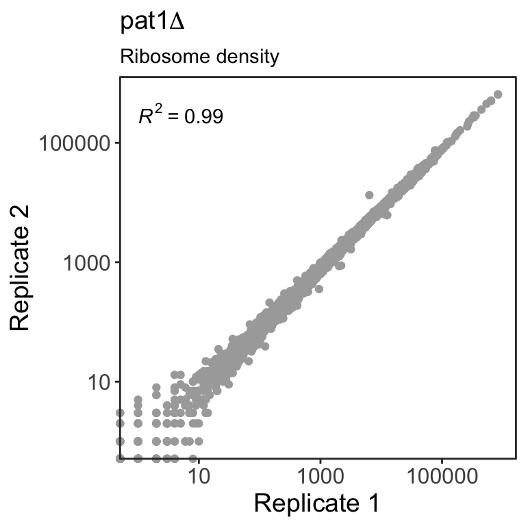

```r
ggplot(raw_count, aes(x = ribo_pat_repA , y = ribo_pat_repB)) +
  geom_point(color = "darkgrey") + stat_cor(aes(label = paste(..rr.label..))) + #no p-value label
  scale_y_log10(labels = scales::number_format(big.mark = '')) + #bigmark get rids of space between numbers
  scale_x_log10(labels = scales::number_format(big.mark = '')) +
  theme_bw() +
  theme(panel.grid.major = element_blank(), panel.grid.minor = element_blank(), axis.title = element_text(size = 14), plot.title = element_text(size = 14, face = "bold.italic"),
    axis.text = element_text(size = 12)) +
  coord_cartesian(clip = 'off') +
  labs(x = "Replicate 1", y = "Replicate 2",
  title = expression("pat1"*Delta),
  subtitle = "Ribosome density")
```

There are about 185 missing values from stat_Cor. log of 0 will give infinite value, thats why? But stat_cor is before log transformation of axes, shouldn’t it take precedence?

```r
anyNA(raw_count)
```

```
## [1] FALSE
```

```r
dim(raw_count)
```

```
## [1] 5647   31
```

```r
raw_count1 <- raw_count %>%
  select(ribo_pat_repA, ribo_pat_repB) %>%
  filter(ribo_pat_repA > 0, ribo_pat_repB > 0)
dim(raw_count1)
```

```
## [1] 5462    2
```

OK, so those missing values are due to counts = 0. Testing correlation

```r
cor.test(raw_count$ribo_pat_repA, raw_count$ribo_pat_repB, method = "pearson")
```

```
##
##  Pearson's product-moment correlation
##
## data:  raw_count$ribo_pat_repA and raw_count$ribo_pat_repB
## t = 1806.6, df = 5645, p-value < 2.2e-16
## alternative hypothesis: true correlation is not equal to 0
## 95 percent confidence interval:
##  0.9990901 0.9991802
## sample estimates:
##       cor
## 0.9991364
```

Now, make a graph with 0 counts removed. The warning is gone.

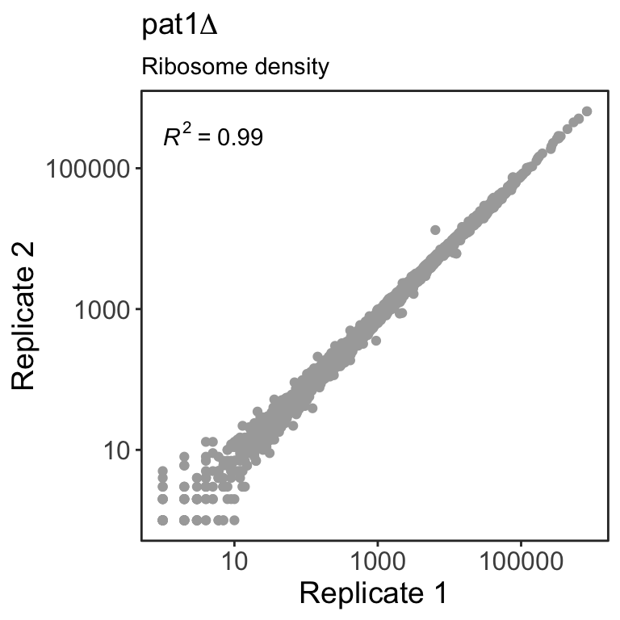

```r
ggplot(raw_count1, aes(x = ribo_pat_repA , y = ribo_pat_repB)) +
  geom_point(color = "darkgrey") + stat_cor(aes(label = paste(..rr.label..))) +
  scale_y_log10(labels = scales::number_format(big.mark = '')) +
  scale_x_log10(labels = scales::number_format(big.mark = '')) +
  theme_bw() +
  theme(panel.grid.major = element_blank(), panel.grid.minor = element_blank(), axis.title = element_text(size = 14), plot.title = element_text(size = 14, face = "italic"),
    axis.text = element_text(size = 12)) +
  coord_cartesian(clip = 'off') +
  labs(x = "Replicate 1", y = "Replicate 2",
  title = expression("pat1"*Delta),
  subtitle = "Ribosome density")
```

```r
#ggsave("pat1_ribo_repAB.pdf", height = 4, width = 4)
```

Similarly, do for the RNA-seq samples

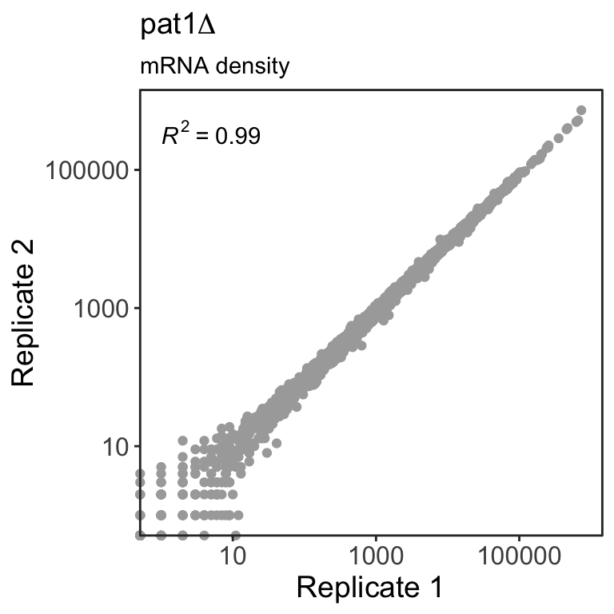

```r
ggplot(raw_count, aes(x = mRNA_pat_repA , y = mRNA_pat_repB)) +
  geom_point(color = "darkgrey") + stat_cor(aes(label = paste(..rr.label..))) +
  scale_y_log10(labels = scales::number_format(big.mark = '')) +
  scale_x_log10(labels = scales::number_format(big.mark = '')) +
  theme_bw() +
  theme(panel.grid.major = element_blank(), panel.grid.minor = element_blank(), axis.title = element_text(size = 14), plot.title = element_text(size = 14),
    axis.text = element_text(size = 12)) +
  coord_cartesian(clip = 'off') +
  labs(x = "Replicate 1", y = "Replicate 2",
  title = expression("pat1"*Delta),
  subtitle = "mRNA density")
```

Did the same analysis for all replicates of WT and mutants, found a correlation of 0.98-0.99.

Proceed with DeSeq2 analysis (Bioconductors), and started looking for differential expression. We have a script in the lab for Deseq2 analysis. Changed minimum read counts for RNA-seq to 128 and ribo-seq to 32. The script generates 6 files and the information needs to be combined for subsequent analysis.

First, I merged 6 or so files together for each pair.

```r
#pat_norm_count <- read.delim("./pat1_WT/pat1_vs_WT_Normalized_counts.txt", header = TRUE, sep = "\t")
#pat_mRNA <- read.delim("./pat1_WT/pat1_mRNA_change_vs_WT.txt", header = TRUE, sep = "\t")
#pat_ribo <- read.delim("./pat1_WT/pat1_Ribo_change_vs_WT.txt", header = TRUE, sep = "\t")

#pat_patTE <- read.delim("./pat1_WT/pat1_TE_with_WT.txt", header = TRUE, sep = "\t")

#pat_WTTE <- read.delim("./pat1_WT/WT_TE_with_pat1.txt", header = TRUE, sep = "\t")

#pat_TEchange <- read.delim("./pat1_WT/TE_change_pat1_vs_WT.txt", header = TRUE, sep = "\t")

#First, looking at the normalized read count file.


#head(pat_norm_count)
#colnames(pat_norm_count)
#colSums(pat_norm_count)


#Changing column names:


#pat_norm_count_1 <- pat_norm_count %>%
  #set_names(str_replace_all(names(.), '_counts.txt', '')) %>%
  #set_names(str_replace(names(.), '_rna', '')) %>%
  #set_names(str_replace(names(.), '_fp','')) %>%
  #set_names(str_replace(names(.), "_1", "_repA")) %>%
  #set_names(str_replace(names(.), "_2", "_repB")) %>%
  #set_names(str_replace(names(.), "_3", "_repC"))
#colnames(pat_norm_count_1)

#The number of rows are equal, and same gene are represented in the same order so can using cbind.


#str(pat_mRNA)
#str(pat_norm_count_1)
#str looks good

#anyNA(pat_mRNA)
#anyNA(pat_norm_count_1)
# No missing values

#new_pat1 <- cbind(pat_mRNA, pat_norm_count_1)
#head(new_pat1)
```

Similarly, I combined all 6 files, changed the column names, removed duplicate or unnecessary column to create a table for all files together. Saved it as a txt and csv file.

```r
pat_combined <- read_csv("pat1_combined_data.csv")
head(pat_combined)
```

```
## # A tibble: 6 x 33
##   TEchange_gene_ID gene_name TEchange_log2FC `TEchange_p-val` TEchange_FDR
##   <chr>            <chr>               <dbl>            <dbl>        <dbl>
## 1 YAL067C          SEO1               0.197      0.366         0.611
## 2 YAL063C          FLO9               0.422      0.0158        0.0840
## 3 YAL054C          ACS1               1.06       0.0000000181  0.000000820
## 4 YAL049C          AIM2               0.196      0.0226        0.107
## 5 YAL047C          SPC72             -0.0134     0.897         0.956
## 6 YAL046C          AIM1              -0.0473     0.573         0.768
## # ... with 28 more variables: WTTE_log2FC <dbl>, `WTTE_p-val` <dbl>,
## #   WTTE_FDR <dbl>, WTTE_gene_ID <chr>, patTE_log2FC <dbl>,
## #   `patTE_p-val` <dbl>, patTE_FDR <dbl>, patTE_gene_ID <chr>,
## #   ribo_log2FC <dbl>, `ribo_p-val` <dbl>, ribo_FDR <dbl>,
## #   ribo_gene_ID <chr>, mRNA_log2FC <dbl>, `mRNA_p-val` <dbl>,
## #   mRNA_FDR <dbl>, mRNA_gene_ID <chr>, mRNA_WT_repA <dbl>,
## #   mRNA_WT_repB <dbl>, mRNA_WT_repC <dbl>, mRNA_pat_repA <dbl>,
## #   mRNA_pat_repB <dbl>, mRNA_pat_repC <dbl>, ribo_WT_repA <dbl>,
## #   ribo_WT_repB <dbl>, ribo_WT_repC <dbl>, ribo_pat_repA <dbl>,
## #   ribo_pat_repB <dbl>, ribo_pat_repC <dbl>
```

Now, I need to calculate the means for the mRNA and ribo-reads.

```r
pat1_combined <- pat_combined %>%
  select(-'TEchange_p-val', -'WTTE_p-val', -WTTE_gene_ID, -'patTE_p-val', -patTE_gene_ID, -'ribo_p-val', -ribo_gene_ID, -'mRNA_p-val', -mRNA_gene_ID) %>%
  mutate(mRNA_WT_mean = rowMeans(select(.,c("mRNA_WT_repA", "mRNA_WT_repB", "mRNA_WT_repC")))) %>%
  mutate(mRNA_pat1_mean = rowMeans(select(.,c("mRNA_pat_repA", "mRNA_pat_repB", "mRNA_pat_repC")))) %>%
  mutate(ribo_WT_mean = rowMeans(select(.,c("ribo_WT_repA", "ribo_WT_repB", "ribo_WT_repC")))) %>%
  mutate(ribo_pat1_mean = rowMeans(select(.,c("ribo_pat_repA", "ribo_pat_repB", "ribo_pat_repC"))))

head(pat1_combined)
```

```
## # A tibble: 6 x 28
##   TEchange_gene_ID gene_name TEchange_log2FC TEchange_FDR WTTE_log2FC
##   <chr>            <chr>               <dbl>        <dbl>       <dbl>
## 1 YAL067C          SEO1               0.197   0.611            -1.42
## 2 YAL063C          FLO9               0.422   0.0840           -2.64
## 3 YAL054C          ACS1               1.06    0.000000820      -2.14
## 4 YAL049C          AIM2               0.196   0.107             0.844
## 5 YAL047C          SPC72             -0.0134  0.956            -0.675
## 6 YAL046C          AIM1              -0.0473  0.768             0.865
## # ... with 23 more variables: WTTE_FDR <dbl>, patTE_log2FC <dbl>,
## #   patTE_FDR <dbl>, ribo_log2FC <dbl>, ribo_FDR <dbl>, mRNA_log2FC <dbl>,
## #   mRNA_FDR <dbl>, mRNA_WT_repA <dbl>, mRNA_WT_repB <dbl>,
## #   mRNA_WT_repC <dbl>, mRNA_pat_repA <dbl>, mRNA_pat_repB <dbl>,
## #   mRNA_pat_repC <dbl>, ribo_WT_repA <dbl>, ribo_WT_repB <dbl>,
## #   ribo_WT_repC <dbl>, ribo_pat_repA <dbl>, ribo_pat_repB <dbl>,
## #   ribo_pat_repC <dbl>, mRNA_WT_mean <dbl>, mRNA_pat1_mean <dbl>,
## #   ribo_WT_mean <dbl>, ribo_pat1_mean <dbl>
```

**mRNA changes in pat1 deletion vs WT**

Now, lets look at mRNA changes. First, collect the required columns otherwise the plot gets too big as seen with TE changes.

```r
mRNA_pat <- pat1_combined %>%
  select(mRNA_log2FC, mRNA_FDR, mRNA_WT_mean, mRNA_pat1_mean)
head(mRNA_pat)
```

```
## # A tibble: 6 x 4
##   mRNA_log2FC  mRNA_FDR mRNA_WT_mean mRNA_pat1_mean
##         <dbl>     <dbl>        <dbl>          <dbl>
## 1       0.720 8.93e-  8         154.           252.
## 2       1.45  1.02e- 59         327.           891.
## 3       2.32  1.81e-103         213.          1060.
## 4       1.28  3.38e- 93        1524.          3695.
## 5       1.15  5.53e- 63         556.          1236.
## 6       1.64  5.03e-150         454.          1414.
```

Next, I filtered the data with FDR < 0.05 and fold-change of 1.5 or 2 or greater. I used this information on the graph.

```r
mpat_filtered_up2 <- mRNA_pat %>%
  filter(mRNA_log2FC > 1) %>%
  filter(mRNA_FDR < 0.05)
dim(mpat_filtered_up2)
```

```
## [1] 364   4
```

```r
mpat_filtered_up1 <- mRNA_pat %>%
  filter(mRNA_log2FC > 0.58) %>%
  filter(mRNA_FDR < 0.05)
dim(mpat_filtered_up1)
```

```
## [1] 756   4
```

```r
mpat_filtered_down2 <- mRNA_pat %>%
  filter(mRNA_log2FC < -1) %>%
  filter(mRNA_FDR < 0.05)
dim(mpat_filtered_down2)
```

```
## [1] 87  4
```

```r
mpat_filtered_down1 <- mRNA_pat %>%
  filter(mRNA_log2FC < -0.58) %>%
  filter(mRNA_FDR < 0.05)
dim(mpat_filtered_down1)
```

```
## [1] 608   4
```

Visualization of the data.

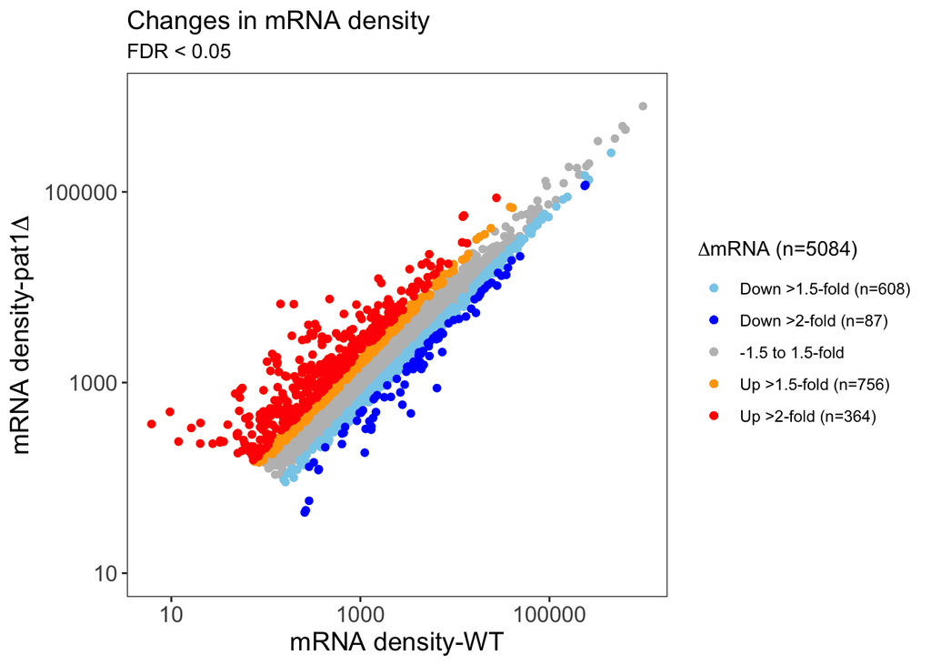

```r
cols1 <- c("Nochange" = "grey", "Up2" = "red", "Down2" = "blue", "Up1" = "orange", "Down1" = "skyblue")
mRNA_p <- ggplot(data = mRNA_pat, aes(x = mRNA_WT_mean, y = mRNA_pat1_mean)) +
  geom_point(aes(color = "Nochange")) +
  scale_y_log10(limits = c(10,1000000), labels = scales::number_format(big.mark = ''), breaks = c(10,1000,100000)) +
  scale_x_log10(labels = scales::number_format(big.mark = ''), breaks = c(10,1000,100000)) +
  theme_bw() +
  theme(panel.grid.major = element_blank(), panel.grid.minor = element_blank(), axis.title = element_text(size = 14), plot.title = element_text(size = 14),
    axis.text = element_text(size = 12)) +
  geom_point(data = mRNA_pat %>% filter(mRNA_log2FC > 0.58 & mRNA_FDR <= 0.05), aes(color = "Up1")) +
  geom_point(data = mRNA_pat %>% filter(mRNA_log2FC < -0.58 & mRNA_FDR <= 0.05), aes(color = "Down1")) +
  geom_point(data = mRNA_pat %>% filter(mRNA_log2FC > 1 & mRNA_FDR <= 0.05), aes(color = "Up2")) +
  geom_point(data = mRNA_pat %>% filter(mRNA_log2FC < -1 & mRNA_FDR <= 0.05), aes(color = "Down2")) +
scale_color_manual(name = expression(Delta*"mRNA (n=5084)"), values = cols1,
                     labels = c("Down >1.5-fold (n=608)", "Down >2-fold (n=87)", "-1.5 to 1.5-fold", "Up >1.5-fold (n=756)", "Up >2-fold (n=364) "))


mRNA_p + labs(x = "mRNA density-WT", y = expression("mRNA density-pat1"*Delta),
  title = "Changes in mRNA density",
  subtitle = "FDR < 0.05")
```

Here, I am looking at TE changes. TE (translational efficiency) is ribo counts/mRNA count, and change is TE = TE mutant/TE WT.

Again calculating the number of genes upregulated or downregulated in pat1 mutant strain.

```r
pat_filtered_up2 <- pat1_combined %>%
  filter(TEchange_log2FC > 1) %>%
  filter(TEchange_FDR < 0.05)
dim(pat_filtered_up2)
```

```
## [1] 60 28
```

```r
pat_filtered_up1 <- pat1_combined %>%
  filter(TEchange_log2FC > 0.58) %>%
  filter(TEchange_FDR < 0.05)
dim(pat_filtered_up1)
```

```
## [1] 123  28
```

```r
pat_filtered_down2 <- pat1_combined %>%
  filter(TEchange_log2FC < -1) %>%
  filter(TEchange_FDR < 0.05)
dim(pat_filtered_down2)
```

```
## [1]  6 28
```

```r
pat_filtered_down1 <- pat1_combined %>%
  filter(TEchange_log2FC < -0.58) %>%
  filter(TEchange_FDR < 0.05)
dim(pat_filtered_down1)
```

```
## [1] 33 28
```

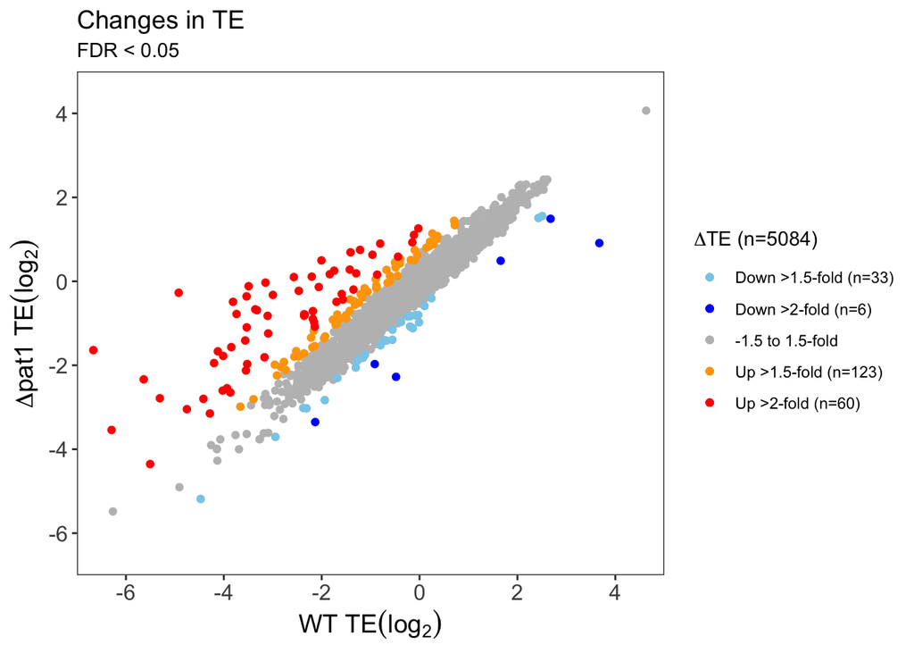

```r
cols1 <- c("Nochange" = "grey", "Up2" = "red", "Down2" = "blue", "Up1" = "orange", "Down1" = "skyblue")
p <- ggplot(data = pat1_combined, aes(x = WTTE_log2FC, y = patTE_log2FC)) +
  geom_point (aes(color = "Nochange")) +
  scale_x_continuous(limits = c(-7,5), breaks = c(-6,-4,-2,0,2,4,6), expand = c(0,0)) +
  scale_y_continuous(limits = c(-7,5), breaks = c(-6,-4,-2,0,2,4,6), expand = c(0,0)) +
  theme_bw() +
  theme(panel.grid.major = element_blank(), panel.grid.minor = element_blank(), axis.title = element_text(size = 14), plot.title = element_text(size = 14),
    axis.text = element_text(size = 12)) +
  geom_point(data = pat1_combined %>% filter(TEchange_log2FC > 0.58 & TEchange_FDR <= 0.05), aes(color = "Up1")) +
  geom_point(data = pat1_combined %>% filter(TEchange_log2FC < -0.58 & TEchange_FDR <= 0.05), aes(color = "Down1")) +
  geom_point(data = pat1_combined %>% filter(TEchange_log2FC > 1 & TEchange_FDR <= 0.05), aes(color = "Up2")) +
  geom_point(data = pat1_combined %>% filter(TEchange_log2FC < -1 & TEchange_FDR <= 0.05), aes(color = "Down2")) +
scale_color_manual(name = expression(Delta*"TE (n=5084)"), values = cols1,
                     labels = c("Down >1.5-fold (n=33)", "Down >2-fold (n=6)", "-1.5 to 1.5-fold", "Up >1.5-fold (n=123)", "Up >2-fold (n=60) "))


p + labs(x = expression("WT TE"(log[2])), y = expression(Delta*"pat1 TE"(log[2])),
  title = "Changes in TE",
  subtitle = "FDR < 0.05")
```

For summary statistics, sometimes only the FDR cutoff is used, since fold-change can be arbitarary. Since, there aren’t “many” genes that undergo changes according to fold-change cutoff, I wanted to take a look at relationship between FC and FDR. This is like an upside version of volcano plot.

```r
FDR_TE <- pat1_combined %>%
  select(TEchange_log2FC, TEchange_FDR)
FDR_TE2 <- FDR_TE %>%
  filter(TEchange_FDR <0.05) %>%
  filter(TEchange_log2FC > 0)
  #filter(TEchange_log2FC < 0)

dim(FDR_TE2)
```

```
## [1] 377   2
```

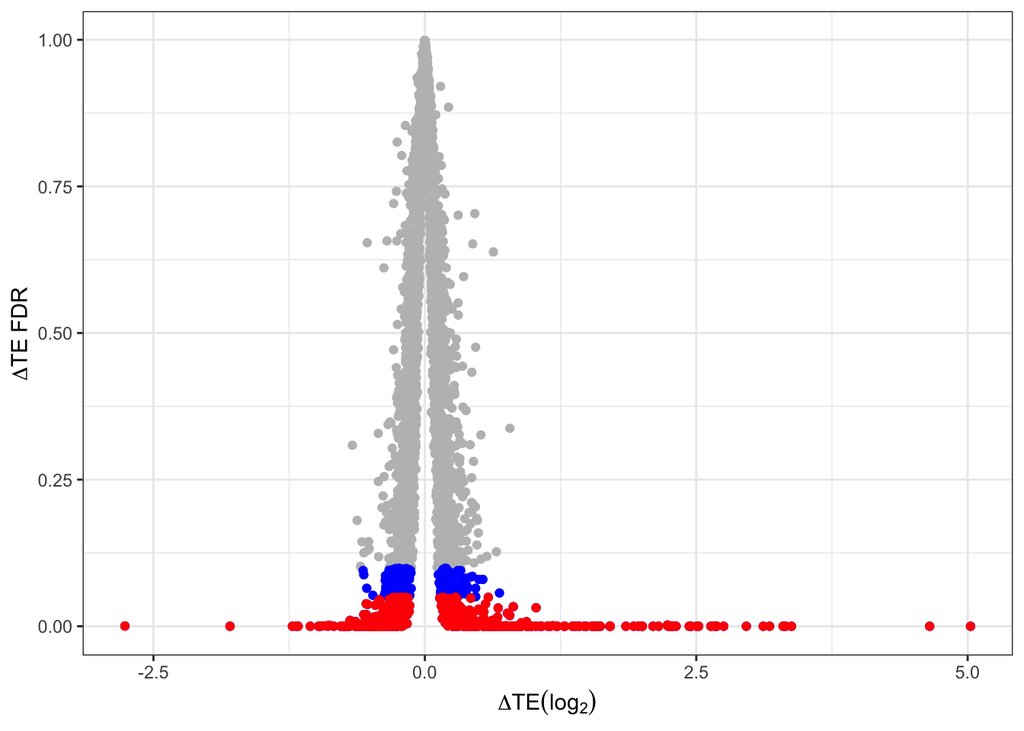

```r
 #0.1= 473 up 0.05 = 377
#0.1 = 559 down 0.05 = 401
  ggplot(FDR_TE, aes(TEchange_log2FC, TEchange_FDR)) +
    geom_point(color="grey") +
    theme_bw() +
    geom_point(data = FDR_TE %>% filter (TEchange_FDR < 0.1), color = "blue") +
    geom_point(data = FDR_TE %>% filter (TEchange_FDR < 0.05), color = "red") +
   labs(y = expression(Delta*"TE FDR"), x = expression(Delta*"TE" (log[2])))
```

I am looking at the relationship of genes that are up- or down-regulated in Pat1 deletion strain with dhh1 and pat1dhh1 deletion strains. Are they also affected in these strains?

```r
pat <- read_csv("pat1_combined_data.csv")
dhh <- read_csv("dhh1_combined_data.csv")
pd <- read_csv("pat1dhh1_combined_data.csv")
```

Since all three files have the same/similar column names, I am changing to distinguish them. Here, only analysis with mRNA samples is shown. Similar analysis is done with TE change data.

```r
#head(pat)
pat1 <- pat %>%
  select(TEchange_gene_ID, mRNA_log2FC, mRNA_FDR)

names(pat1)[1] <- "pat_gene_ID"
names(pat1)[2] <- "pat_mRNA_FC"
names(pat1)[3] <- "pat_mRNA_FDR"

head(pat1)
```

```
## # A tibble: 6 x 3
##   pat_gene_ID pat_mRNA_FC pat_mRNA_FDR
##   <chr>             <dbl>        <dbl>
## 1 YAL067C           0.720    8.93e-  8
## 2 YAL063C           1.45     1.02e- 59
## 3 YAL054C           2.32     1.81e-103
## 4 YAL049C           1.28     3.38e- 93
## 5 YAL047C           1.15     5.53e- 63
## 6 YAL046C           1.64     5.03e-150
```

```r
#head(dhh)
dhh1 <- dhh %>%
  select(TEchange_gene_ID, mRNA_log2FC, mRNA_FDR)

names(dhh1)[1] <- "dhh_gene_ID"
names(dhh1)[2] <- "dhh_mRNA_FC"
names(dhh1)[3] <- "dhh_mRNA_FDR"

head(dhh1)
```

```
## # A tibble: 6 x 3
##   dhh_gene_ID dhh_mRNA_FC dhh_mRNA_FDR
##   <chr>             <dbl>        <dbl>
## 1 YAL067C        -0.630      0.0250
## 2 YAL063C         0.118      0.729
## 3 YAL054C         1.35       0.0000959
## 4 YAL049C         0.00480    0.980
## 5 YAL047C        -0.117      0.624
## 6 YAL046C        -0.186      0.381
```

```r
#head(pd)
pd1 <- pd %>%
  select(TEchange_gene_ID, mRNA_log2FC, mRNA_FDR)

names(pd1)[1] <- "pd_gene_ID"
names(pd1)[2] <- "pd_mRNA_FC"
names(pd1)[3] <- "pd_mRNA_FDR"

head(pd1)
```

```
## # A tibble: 6 x 3
##   pd_gene_ID pd_mRNA_FC pd_mRNA_FDR
##   <chr>           <dbl>       <dbl>
## 1 YAL063C       0.808      2.25e- 8
## 2 YAL054C       2.94       5.44e-18
## 3 YAL049C      -0.0651     4.07e- 1
## 4 YAL047C      -0.00845    9.44e- 1
## 5 YAL046C       0.302      2.99e- 3
## 6 YAL044C       0.597      5.61e-17
```

```r
#str(pd1)
```

Ideally, there shouldn’t be any NA or 0 in the dataset.

```r
anyNA(pat1)
```

```
## [1] FALSE
```

```r
anyNA(dhh1)
```

```
## [1] FALSE
```

```r
anyNA(pd1)
```

```
## [1] FALSE
```

Since, in this dataset, I am looking at the pat1 regulated genes, I am combining genes that are present in pat1. The other dataset have overlapping but distinct set of genes.

```r
comb1 <- left_join(pat1, pd1, by=c("pat_gene_ID"="pd_gene_ID"))

head(comb1)
```

```
## # A tibble: 6 x 5
##   pat_gene_ID pat_mRNA_FC pat_mRNA_FDR pd_mRNA_FC pd_mRNA_FDR
##   <chr>             <dbl>        <dbl>      <dbl>       <dbl>
## 1 YAL067C           0.720    8.93e-  8   NA         NA
## 2 YAL063C           1.45     1.02e- 59    0.808      2.25e- 8
## 3 YAL054C           2.32     1.81e-103    2.94       5.44e-18
## 4 YAL049C           1.28     3.38e- 93   -0.0651     4.07e- 1
## 5 YAL047C           1.15     5.53e- 63   -0.00845    9.44e- 1
## 6 YAL046C           1.64     5.03e-150    0.302      2.99e- 3
```

```r
combined <- left_join(comb1, dhh1, by=c("pat_gene_ID"="dhh_gene_ID"))

head(combined)
```

```
## # A tibble: 6 x 7
##   pat_gene_ID pat_mRNA_FC pat_mRNA_FDR pd_mRNA_FC pd_mRNA_FDR dhh_mRNA_FC
##   <chr>             <dbl>        <dbl>      <dbl>       <dbl>       <dbl>
## 1 YAL067C           0.720    8.93e-  8   NA         NA           -0.630
## 2 YAL063C           1.45     1.02e- 59    0.808      2.25e- 8     0.118
## 3 YAL054C           2.32     1.81e-103    2.94       5.44e-18     1.35
## 4 YAL049C           1.28     3.38e- 93   -0.0651     4.07e- 1     0.00480
## 5 YAL047C           1.15     5.53e- 63   -0.00845    9.44e- 1    -0.117
## 6 YAL046C           1.64     5.03e-150    0.302      2.99e- 3    -0.186
## # ... with 1 more variable: dhh_mRNA_FDR <dbl>
```

```r
dim(combined)
```

```
## [1] 5084    7
```

```r
mRNA <- combined %>%
  filter(pat_mRNA_FDR < 0.05 & pat_mRNA_FC > 0)
dim(mRNA)
```

```
## [1] 1771    7
```

```r
mRNA_2 <- mRNA %>%
  select(pat_gene_ID, pat_mRNA_FC, dhh_mRNA_FC, pd_mRNA_FC) %>%
  set_names(str_replace(names(.), "_mRNA_FC", "1")) %>%
  set_names(str_replace(names(.), "pd1", "pat1dhh1")) %>%


  gather(sample, change, -pat_gene_ID)

head(mRNA_2)
```

```
## # A tibble: 6 x 3
##   pat_gene_ID sample change
##   <chr>       <chr>   <dbl>
## 1 YAL067C     pat1    0.720
## 2 YAL063C     pat1    1.45
## 3 YAL054C     pat1    2.32
## 4 YAL049C     pat1    1.28
## 5 YAL047C     pat1    1.15
## 6 YAL046C     pat1    1.64
```

```r
anyNA(mRNA_2)
```

```
## [1] TRUE
```

```r
mRNA_3 <- mRNA_2 %>% drop_na()

anyNA(mRNA_3)
```

```
## [1] FALSE
```

```r
dim(mRNA_3)
```

```
## [1] 5094    3
```

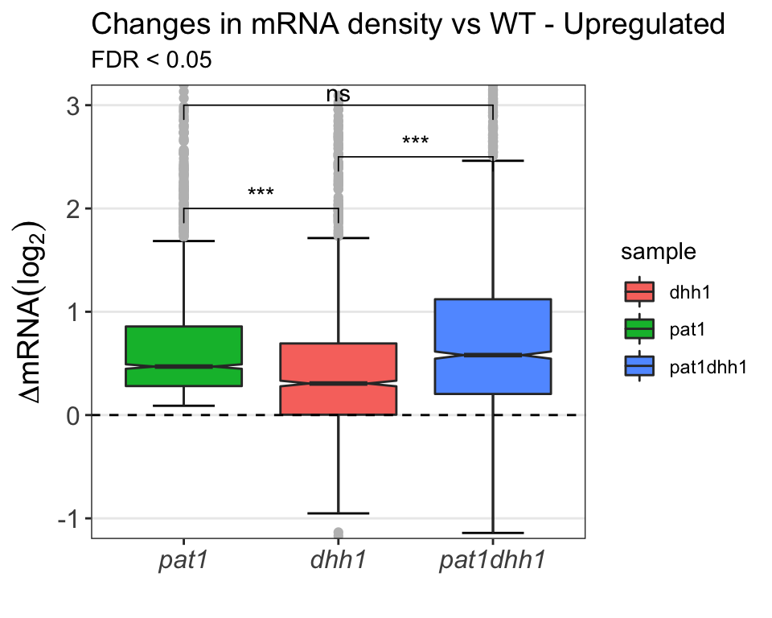

```r
my_comparisons <- list(c('pat1','dhh1'),
c('dhh1','pat1dhh1'),
c('pat1','pat1dhh1'))

symnum.arg <- list(cutpoints = c(0, 0.001, 0.01, 0.05, 1), symbols = c("***", "**", "*", "ns"))

ggplot(mRNA_3, aes(x= sample, y=change, fill = sample)) +
  stat_boxplot(geom ='errorbar', width = 0.4) +
  geom_boxplot(notch = TRUE, outlier.color = "grey") +
  stat_compare_means(data = mRNA_3, method = "wilcox.test" , comparisons = my_comparisons, label.y = c(2,2.5,3), tip.length = 0.01, symnum.args = symnum.arg, inherit.aes = FALSE) +
  coord_cartesian(ylim = c(-1,3)) + # it acts as zooming into the plot, doesn't change the underlying data for stat_compare_mean
  #scale_y_continuous(limits = c(-1,3)) + #this acually scales the data, throwing statistics off
  scale_x_discrete(limits = c("pat1", "dhh1", "pat1dhh1")) +
  theme_bw() +
  theme(panel.grid.minor = element_blank(), axis.title = element_text(size = 14), plot.title = element_text(size = 14), panel.grid.major.x = element_blank(),
    axis.text = element_text(size = 12), axis.text.x = element_text(face = "italic")) +
  geom_hline(yintercept = 0, color = "black", linetype = "dashed" ) +
  labs(x = "", y = expression(Delta*"mRNA"(log[2])),
  title = "Changes in mRNA density vs WT - Upregulated",
  subtitle = "FDR < 0.05")
```

```r
mRNA_4 <- combined %>%
  filter(pat_mRNA_FDR < 0.05 & pat_mRNA_FC > 0.58) %>%
  select(pat_gene_ID, pat_mRNA_FC, dhh_mRNA_FC, pd_mRNA_FC) %>%
  set_names(str_replace(names(.), "_mRNA_FC", "1")) %>%
  set_names(str_replace(names(.), "pd1", "pat1dhh1")) %>%
  gather(sample, change, -pat_gene_ID) %>%
  drop_na()

head(mRNA_4)
```

```
## # A tibble: 6 x 3
##   pat_gene_ID sample change
##   <chr>       <chr>   <dbl>
## 1 YAL067C     pat1    0.720
## 2 YAL063C     pat1    1.45
## 3 YAL054C     pat1    2.32
## 4 YAL049C     pat1    1.28
## 5 YAL047C     pat1    1.15
## 6 YAL046C     pat1    1.64
```

```r
dim(mRNA_4)
```

```
## [1] 2096    3
```

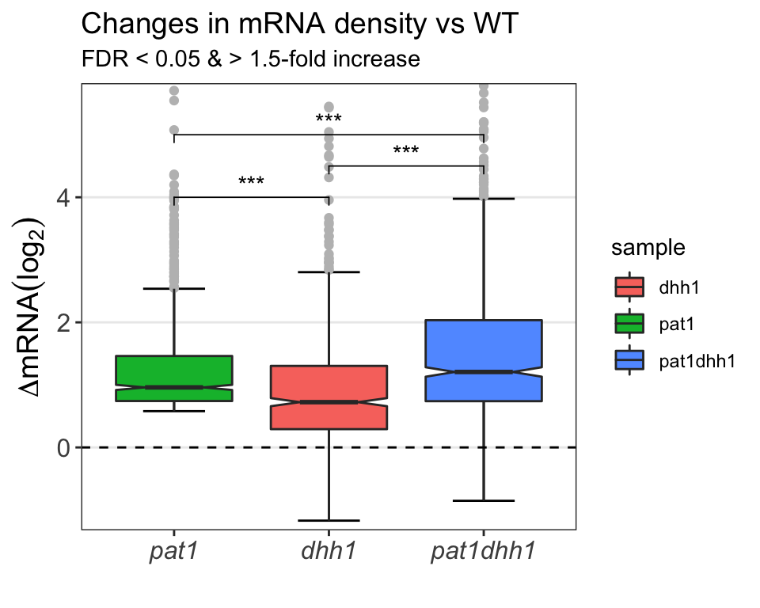

```r
my_comparisons <- list(c('pat1','dhh1'),
c('dhh1','pat1dhh1'),
c('pat1','pat1dhh1'))

symnum.arg <- list(cutpoints = c(0, 0.001, 0.01, 0.05, 1), symbols = c("***", "**", "*", "ns"))

ggplot(mRNA_4, aes(x= sample, y=change, fill = sample)) +
  stat_boxplot(geom ='errorbar', width = 0.4) +
  geom_boxplot(notch = TRUE, outlier.color = "grey") +
  stat_compare_means(method = "wilcox.test" , comparisons = my_comparisons, label.y = c(4,4.5,5), tip.length = 0.01, symnum.args = symnum.arg) +
  coord_cartesian(ylim = c(-1,5.5)) +
  #scale_y_continuous(limits = c(-1,5.5)) +
  scale_x_discrete(limits = c("pat1", "dhh1", "pat1dhh1")) +
  theme_bw() +
  theme(panel.grid.minor = element_blank(), axis.title = element_text(size = 14), plot.title = element_text(size = 14), panel.grid.major.x = element_blank(),
    axis.text = element_text(size = 12), axis.text.x = element_text(face = "italic")) +
  geom_hline(yintercept = 0, color = "black", linetype = "dashed" ) +
  labs(x = "", y = expression(Delta*"mRNA" (log[2])),
  title = "Changes in mRNA density vs WT",
  subtitle = "FDR < 0.05 & > 1.5-fold increase")
```

```r
mRNA_5 <- combined %>%
  filter(pat_mRNA_FDR < 0.05 & pat_mRNA_FC < 0) %>%
  select(pat_gene_ID, pat_mRNA_FC, dhh_mRNA_FC, pd_mRNA_FC) %>%
  set_names(str_replace(names(.), "_mRNA_FC", "1")) %>%
  set_names(str_replace(names(.), "pd1", "pat1dhh1")) %>%
  gather(sample, change, -pat_gene_ID) %>%
  drop_na()

dim(mRNA_5)
```

```
## [1] 6531    3
```

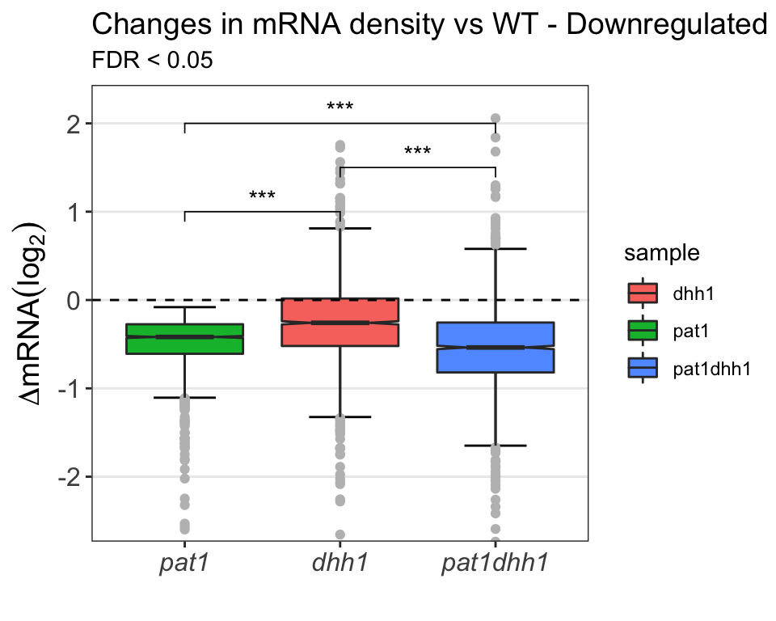

```r
my_comparisons <- list(c('pat1','dhh1'),
c('dhh1','pat1dhh1'),
c('pat1','pat1dhh1'))

symnum.arg <- list(cutpoints = c(0, 0.001, 0.01, 0.05, 1), symbols = c("***", "**", "*", "ns"))

ggplot(mRNA_5, aes(x= sample, y=change, fill = sample)) +
  stat_boxplot(geom ='errorbar', width = 0.4) +
  geom_boxplot(notch = TRUE, outlier.color = "grey") +
  stat_compare_means(method = "wilcox.test" , comparisons = my_comparisons, label.y = c(1,1.5,2), tip.length = 0.01, symnum.args = symnum.arg) +
  coord_cartesian(ylim = c(-2.5,2.2)) +
  #scale_y_continuous(limits = c(-2.5,2.2)) +
  scale_x_discrete(limits = c("pat1", "dhh1", "pat1dhh1")) +
  theme_bw() +
  theme(panel.grid.minor = element_blank(), axis.title = element_text(size = 14), plot.title = element_text(size = 14), panel.grid.major.x = element_blank(),
    axis.text = element_text(size = 12), axis.text.x = element_text(face = "italic")) +
  geom_hline(yintercept = 0, color = "black", linetype = "dashed" ) +
  labs(x = "", y = expression(Delta*"mRNA" (log[2])),
  title = "Changes in mRNA density vs WT - Downregulated",
  subtitle = "FDR < 0.05")
```

```r
mRNA_6 <- combined %>%
  filter(pat_mRNA_FDR < 0.05 & pat_mRNA_FC < -0.58) %>%
  select(pat_gene_ID, pat_mRNA_FC, dhh_mRNA_FC, pd_mRNA_FC) %>%
  set_names(str_replace(names(.), "_mRNA_FC", "1")) %>%
  set_names(str_replace(names(.), "pd1", "pat1dhh1")) %>%
  gather(sample, change, -pat_gene_ID) %>%
  drop_na()
  #mutate(sample = fct_relevel(sample, "pat_mRNA_FC", "dhh_mRNA_FC", "pd_mRNA_FC"))

dim(mRNA_6)
```

```
## [1] 1809    3
```

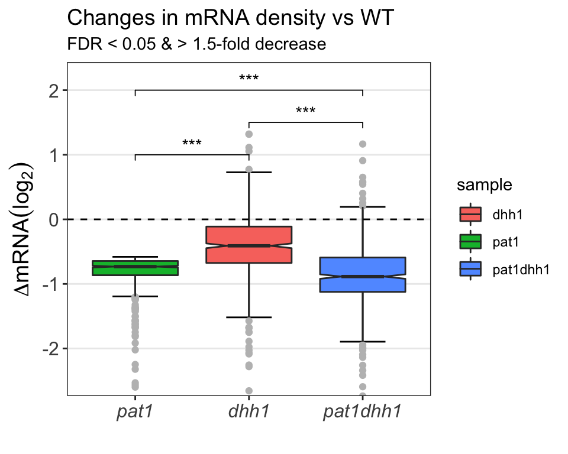

```r
my_comparisons <- list(c('pat1','dhh1'),
c('dhh1','pat1dhh1'),
c('pat1','pat1dhh1'))

symnum.arg <- list(cutpoints = c(0, 0.001, 0.01, 0.05, 1), symbols = c("***", "**", "*", "ns"))

ggplot(mRNA_6, aes(x= sample, y=change, fill = sample)) +
  stat_boxplot(geom ='errorbar', width = 0.4) +
  geom_boxplot(notch = TRUE, outlier.color = "grey") +
  stat_compare_means(method = "wilcox.test" , comparisons = my_comparisons, label.y = c(1,1.5,2), tip.length = 0.01, symnum.args = symnum.arg) +
  coord_cartesian(ylim = c(-2.5,2.2)) +
 # scale_y_continuous(limits = c(-2.5,2.2)) +
  scale_x_discrete(limits = c("pat1", "dhh1", "pat1dhh1")) +
  theme_bw() +
  theme(panel.grid.minor = element_blank(), axis.title = element_text(size = 14), plot.title = element_text(size = 14), panel.grid.major.x = element_blank(),
    axis.text = element_text(size = 12), axis.text.x = element_text(face = "italic")) +
  geom_hline(yintercept = 0, color = "black", linetype = "dashed" ) +
  labs(x = "", y = expression(Delta*"mRNA" (log[2])),
  title = "Changes in mRNA density vs WT",
  subtitle = "FDR < 0.05 & > 1.5-fold decrease")
```

There seems to be an overlap between mRNAs that are regulated by pat1 are also regulated by dhh1.

Then, I wanted to test if it is true for all mRNAs.

Heatmap

Collecting appropriate data.

```r
head(combined)
```

```
## # A tibble: 6 x 7
##   pat_gene_ID pat_mRNA_FC pat_mRNA_FDR pd_mRNA_FC pd_mRNA_FDR dhh_mRNA_FC
##   <chr>             <dbl>        <dbl>      <dbl>       <dbl>       <dbl>
## 1 YAL067C           0.720    8.93e-  8   NA         NA           -0.630
## 2 YAL063C           1.45     1.02e- 59    0.808      2.25e- 8     0.118
## 3 YAL054C           2.32     1.81e-103    2.94       5.44e-18     1.35
## 4 YAL049C           1.28     3.38e- 93   -0.0651     4.07e- 1     0.00480
## 5 YAL047C           1.15     5.53e- 63   -0.00845    9.44e- 1    -0.117
## 6 YAL046C           1.64     5.03e-150    0.302      2.99e- 3    -0.186
## # ... with 1 more variable: dhh_mRNA_FDR <dbl>
```

```r
mRNA_h <- combined %>%
  select(-pat_mRNA_FDR,-pd_mRNA_FDR, -dhh_mRNA_FDR, -pat_gene_ID) %>%
  set_names(str_replace(names(.), "_mRNA_FC", "")) %>%
  drop_na()

mRNA_h1 <- mRNA_h[,c(1,3,2)]
head(mRNA_h1)
```

```
## # A tibble: 6 x 3
##     pat      dhh       pd
##   <dbl>    <dbl>    <dbl>
## 1  1.45  0.118    0.808
## 2  2.32  1.35     2.94
## 3  1.28  0.00480 -0.0651
## 4  1.15 -0.117   -0.00845
## 5  1.64 -0.186    0.302
## 6  1.49  0.492    0.597
```

```r
head(mRNA_h)
```

```
## # A tibble: 6 x 3
##     pat       pd      dhh
##   <dbl>    <dbl>    <dbl>
## 1  1.45  0.808    0.118
## 2  2.32  2.94     1.35
## 3  1.28 -0.0651   0.00480
## 4  1.15 -0.00845 -0.117
## 5  1.64  0.302   -0.186
## 6  1.49  0.597    0.492
```

```r
dim(mRNA_h)
```

```
## [1] 4777    3
```

```r
str(mRNA_h)
```

```
## Classes 'tbl_df', 'tbl' and 'data.frame':    4777 obs. of  3 variables:
##  $ pat: num  1.45 2.32 1.28 1.15 1.64 ...
##  $ pd : num  0.80831 2.9375 -0.06509 -0.00845 0.3018 ...
##  $ dhh: num  0.1182 1.353 0.0048 -0.1171 -0.1859 ...
```

```r
mRNA_h2 <-  data.matrix(mRNA_h1)
head(mRNA_h2)
```

```
##           pat          dhh          pd
## [1,] 1.447031  0.118170173  0.80830607
## [2,] 2.317785  1.352995000  2.93750030
## [3,] 1.276213  0.004801524 -0.06509376
## [4,] 1.153527 -0.117116751 -0.00844742
## [5,] 1.638963 -0.185914323  0.30179834
## [6,] 1.488186  0.492428158  0.59659985
```

```r
str(mRNA_h2)
```

```
##  num [1:4777, 1:3] 1.45 2.32 1.28 1.15 1.64 ...
##  - attr(*, "dimnames")=List of 2
##   ..$ : NULL
##   ..$ : chr [1:3] "pat" "dhh" "pd"
```

```r
library(gplots)
library(RColorBrewer)
```

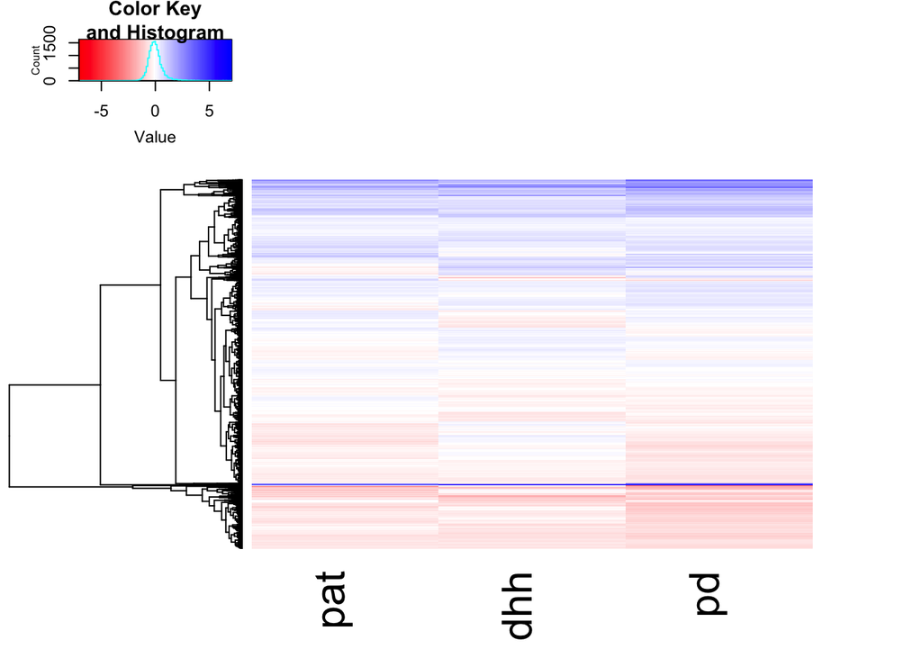

```r
#pdf(file = "mRNA_changes.pdf")
heatmap.2(mRNA_h2, dend="row",
            col=colorRampPalette(c("red","white","blue"), bias=1.01)(n=100),
            labRow=c(""), trace="none", Colv = FALSE)
```

```r
#dev.off()
```

The heatmap doesn’t reflect the changes of 1.5 fold well (too white). Changing color scheme

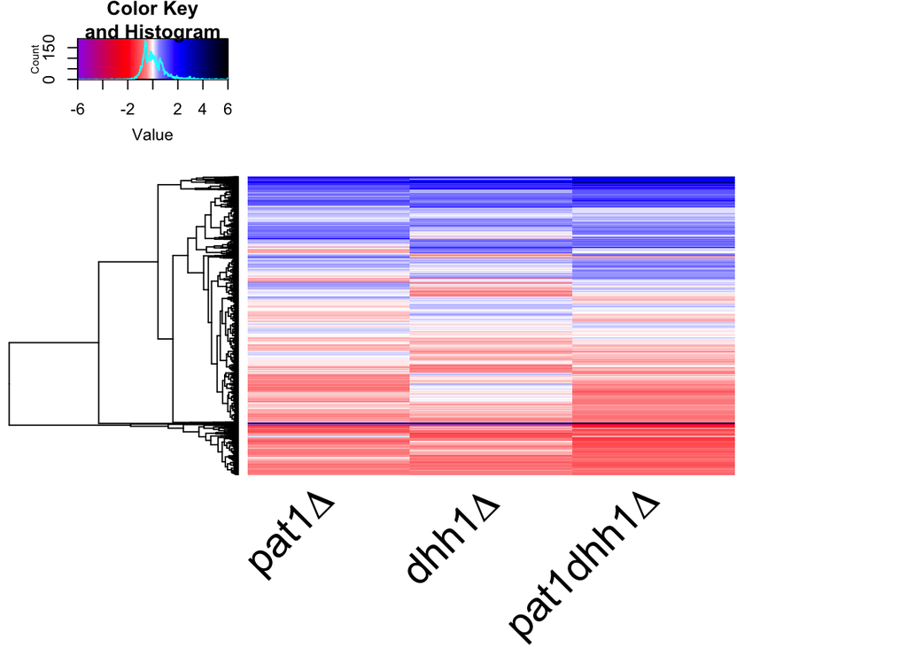

```r
my_palette <- colorRampPalette(c("purple","red","white","blue","black"))(n=499)
col_breaks <- c(seq(-6,-3,length=100),
                seq(-2.9,-0.51,length=100),
                seq(-0.5,0.5,length=100),
  seq(0.51,2.9,length=100),
  seq(3,6,length=100))
anno <- c(expression("pat1"*Delta), expression("dhh1"*Delta), expression("pat1dhh1"*Delta))
#my_palette <- colorRampPalette(rev(brewer.pal(8, "Spectral")))(n=60)
#pdf(file ="hm2.pdf")
heatmap.2(mRNA_h2, dend="row",
            col= my_palette,
            labRow=c(""), trace="none", Colv = FALSE, breaks= col_breaks, labCol = anno, srtCol = 45,
            margins = c(8,8))
```

```r
#dev.off()
```